# Transform Data

# dplyr

## Your Turn 1

Alter the code to select just the `n` column:

```r
select(babynames, n)
```

| n |
| --- |
| 7065 |
| 2604 |
| 2003 |
| 1939 |
| 1746 |
| 1578 |
| 1472 |
| 1414 |
| 1320 |
| 1288 |

[output cut: 9990 more lines]

## Quiz

Which of these is NOT a way to select the `name` and `n` columns together?

```r
select(babynames, -c(year, sex, prop))
```

| name | n |
| --- | --- |
| Mary | 7065 |
| Anna | 2604 |
| Emma | 2003 |
| Elizabeth | 1939 |
| Minnie | 1746 |
| Margaret | 1578 |
| Ida | 1472 |
| Alice | 1414 |
| Bertha | 1320 |
| Sarah | 1288 |

[output cut: 9990 more lines]

```r
select(babynames, name:n)
```

| name | n |
| --- | --- |
| Mary | 7065 |
| Anna | 2604 |
| Emma | 2003 |
| Elizabeth | 1939 |
| Minnie | 1746 |
| Margaret | 1578 |
| Ida | 1472 |
| Alice | 1414 |
| Bertha | 1320 |
| Sarah | 1288 |

[output cut: 9990 more lines]

```r
select(babynames, starts_with("n"))
```

| name | n |
| --- | --- |
| Mary | 7065 |
| Anna | 2604 |
| Emma | 2003 |
| Elizabeth | 1939 |
| Minnie | 1746 |
| Margaret | 1578 |
| Ida | 1472 |
| Alice | 1414 |
| Bertha | 1320 |
| Sarah | 1288 |

[output cut: 9990 more lines]

```r
select(babynames, ends_with("n"))
```

| n |
| --- |
| 7065 |
| 2604 |
| 2003 |
| 1939 |
| 1746 |
| 1578 |
| 1472 |
| 1414 |
| 1320 |
| 1288 |

[output cut: 9990 more lines]

## Your Turn 2

Use `filter`, `babynames`, and the logical operators to find:

- All of the names where prop is greater than or equal to 0.08
- All of the children named “Sea”

```r
filter(babynames, prop >= 0.08)
```

| year | sex | name | n | prop |
| --- | --- | --- | --- | --- |
| 1880 | M | John | 9655 | 0.08154561 |
| 1880 | M | William | 9532 | 0.08050676 |
| 1881 | M | John | 8769 | 0.08098299 |

```r
filter(babynames, name == "Sea")
```

| year | sex | name | n | prop |
| --- | --- | --- | --- | --- |
| 1982 | F | Sea | 5 | 2.76e-06 |
| 1985 | M | Sea | 6 | 3.12e-06 |
| 1986 | M | Sea | 5 | 2.60e-06 |
| 1998 | F | Sea | 5 | 2.58e-06 |

## Your Turn 3

Use Boolean operators to return only the rows that contain:

- *Boys* named Sue
- Names that were used by exactly 5 or 6 children in 1880
- Names that are one of Acura, Lexus, or Yugo

```r
filter(babynames, sex == 'M', name == "Sue")
```

| year | sex | name | n | prop |
| --- | --- | --- | --- | --- |
| 1917 | M | Sue | 7 | 7.300e-06 |
| 1927 | M | Sue | 5 | 4.300e-06 |
| 1928 | M | Sue | 5 | 4.380e-06 |
| 1930 | M | Sue | 5 | 4.430e-06 |
| 1931 | M | Sue | 6 | 5.610e-06 |
| 1932 | M | Sue | 7 | 6.520e-06 |
| 1933 | M | Sue | 7 | 6.860e-06 |
| 1934 | M | Sue | 14 | 1.319e-05 |
| 1935 | M | Sue | 13 | 1.216e-05 |
| 1936 | M | Sue | 9 | 8.460e-06 |

[output cut: 42 more lines]

```r
filter(babynames, year == 1880, (n == 5) | (n == 6))
```

| year | sex | name | n | prop |
| --- | --- | --- | --- | --- |
| 1880 | F | Abby | 6 | 6.147e-05 |
| 1880 | F | Aileen | 6 | 6.147e-05 |
| 1880 | F | Alba | 6 | 6.147e-05 |
| 1880 | F | Alda | 6 | 6.147e-05 |
| 1880 | F | Alla | 6 | 6.147e-05 |
| 1880 | F | Alverta | 6 | 6.147e-05 |
| 1880 | F | Ara | 6 | 6.147e-05 |
| 1880 | F | Ardelia | 6 | 6.147e-05 |
| 1880 | F | Ardella | 6 | 6.147e-05 |
| 1880 | F | Arrie | 6 | 6.147e-05 |

[output cut: 445 more lines]

```r
filter(babynames, (name == "Acura") | (name == "Lexus") | (name == "Yugo"))
```

| year | sex | name | n | prop |
| --- | --- | --- | --- | --- |
| 1990 | F | Lexus | 36 | 0.00001753 |
| 1990 | M | Lexus | 12 | 0.00000558 |
| 1991 | F | Lexus | 102 | 0.00005017 |
| 1991 | M | Lexus | 16 | 0.00000755 |
| 1992 | F | Lexus | 193 | 0.00009629 |
| 1992 | M | Lexus | 25 | 0.00001191 |
| 1993 | F | Lexus | 285 | 0.00014458 |
| 1993 | M | Lexus | 30 | 0.00001453 |
| 1994 | F | Lexus | 381 | 0.00019548 |
| 1994 | F | Acura | 6 | 0.00000308 |

[output cut: 47 more lines]

```r
filter(babynames, name %in% c("Acura", "Lexus", "Yugo")) # Same as above
```

| year | sex | name | n | prop |
| --- | --- | --- | --- | --- |
| 1990 | F | Lexus | 36 | 0.00001753 |
| 1990 | M | Lexus | 12 | 0.00000558 |
| 1991 | F | Lexus | 102 | 0.00005017 |
| 1991 | M | Lexus | 16 | 0.00000755 |
| 1992 | F | Lexus | 193 | 0.00009629 |
| 1992 | M | Lexus | 25 | 0.00001191 |
| 1993 | F | Lexus | 285 | 0.00014458 |
| 1993 | M | Lexus | 30 | 0.00001453 |
| 1994 | F | Lexus | 381 | 0.00019548 |
| 1994 | F | Acura | 6 | 0.00000308 |

[output cut: 47 more lines]

## Help Me

What is the smallest value of n? What is the largest?

```r
arrange(babynames, n) # Smallest
```

| year | sex | name | n | prop |
| --- | --- | --- | --- | --- |
| 1880 | F | Adelle | 5 | 5.123e-05 |
| 1880 | F | Adina | 5 | 5.123e-05 |
| 1880 | F | Adrienne | 5 | 5.123e-05 |
| 1880 | F | Albertine | 5 | 5.123e-05 |
| 1880 | F | Alys | 5 | 5.123e-05 |
| 1880 | F | Ana | 5 | 5.123e-05 |
| 1880 | F | Araminta | 5 | 5.123e-05 |
| 1880 | F | Arthur | 5 | 5.123e-05 |
| 1880 | F | Birtha | 5 | 5.123e-05 |
| 1880 | F | Bulah | 5 | 5.123e-05 |

[output cut: 9990 more lines]

```r
arrange(babynames, desc(n))
```

| year | sex | name | n | prop |
| --- | --- | --- | --- | --- |
| 1947 | F | Linda | 99686 | 0.05483812 |
| 1948 | F | Linda | 96209 | 0.05521079 |
| 1947 | M | James | 94756 | 0.05101589 |
| 1957 | M | Michael | 92695 | 0.04237565 |
| 1947 | M | Robert | 91642 | 0.04933934 |
| 1949 | F | Linda | 91016 | 0.05184643 |
| 1956 | M | Michael | 90620 | 0.04225546 |
| 1958 | M | Michael | 90520 | 0.04204290 |
| 1948 | M | James | 88588 | 0.04969695 |
| 1954 | M | Michael | 88514 | 0.04279319 |

[output cut: 9990 more lines]

## Your Turn 4

Use `%>%` to write a sequence of functions that:

1. Filters babynames to just the girls that were born in 2017, *then…*
2. Selects the `name` and `n` columns, *then…*
3. Arranges the results so that the most popular names are near the top.

```r
babynames %>%
  filter(sex == 'F', year == 2017) %>%
  select(name, n) %>%
  arrange(desc(n)) -> girls_2017
```

## Your Turn 5

1. Trim `babynames` to just the rows that contain **your** `name` and **your** `sex`
2. Trim the result to just the columns that will appear in your graph (not strictly necessary, but useful practice)
3. Plot the results as a line graph with `year` on the x axis and `prop` on the y axis

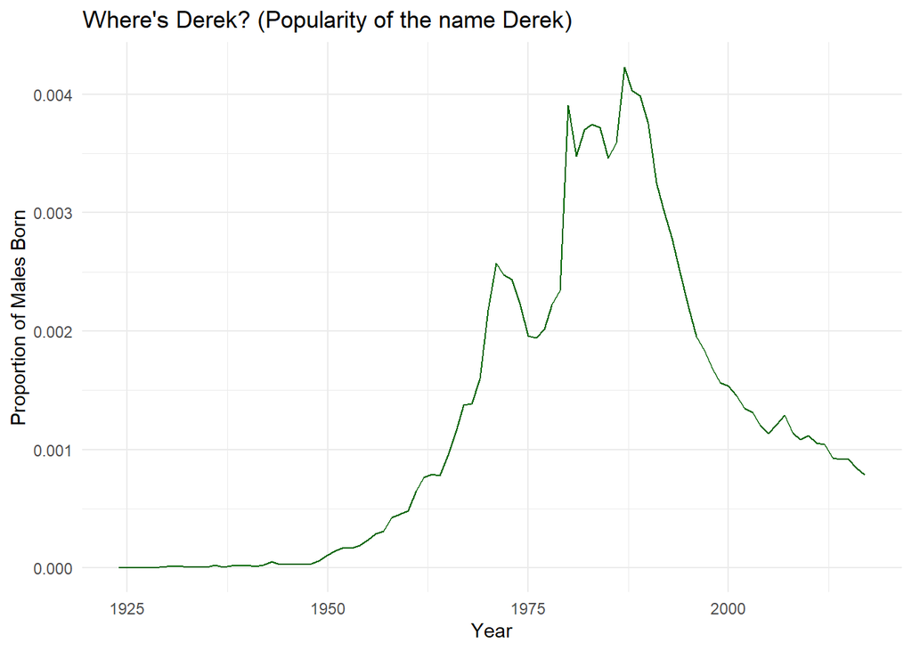

```r
babynames %>%
  filter(name=="Derek", sex=="M") %>%
  select(year, prop) %>%
  ggplot() +
  geom_line(aes(x=year, y=prop), color = "darkgreen") +
  labs(title = "Where's Derek? (Popularity of the name Derek)",
       x = "Year",
       y = "Proportion of Males Born") +
  theme_minimal()
```

# Take aways

- Extract variables with `select()`
- Extract cases with `filter()`
- Arrange cases, with `arrange()`